# Proje Raporu: Ali Buğatekin 170401003

## Q1: Problem Tanımı

Şirketim bir Film Yapım Danışmanlığı Şirketi. film sektöründe etkileyici projeler sunmak ve memnuniyet veren gişe gelirleri elde etmek isteyen yapım şirketleri için güçlü bir film özellik analizi yapılması gerekli.

## Q2: Proje Amacı

Bu projede, IMDb puanlarına göre farklılık gösteren ve https://www.kaggle.com/datasets/isaactaylorofficial/imdb-10000-most-voted-feature-films-041118 adresinde bulunan datasetteki filmlerin özelliklerini analiz edeceğiz. Önce filmleri imdb skorlarına göre “5 ve üstü puana sahip filmler” ve “5 altı puana sahip olan filmler” olarak iki gruba ayıracağız. Daha sonra her iki grupta da en sık görülen film türleri, yönetmenler ve film süreleri özelliklerini keşfedeceğiz. Bunları çeşitli grafik, tablo ve görsellerle ortaya koyarak filmerde bulunan çeşitli özelliklerin IMDB puanlaması üzerindeki etkisini film yapımcılarına sunacağız. Bu sayede film yapım şirketlerine kar artırıcı tavsiyelerde bulunmayı hedefliyoruz.

## Q3: Veri seti keşifsel analizi

Bu projede kullanılan veri seti Kaggle websitesinden indirilmiştir.

Veri boyutları aşağıdaki gibidir:

satır sayısı: 10000 , sütun sayısı: 11

Proje için önemli olan sütunlar şunlardır:

“Director” (Yönetmen): Filmin yönetmeninin adını içerir. Veri tipi karakter (character)dir. “Genre” (Tür): Filmin türünü içerir. Veri tipi karakter (character)dir. “Runtime” (Süre): Filmin süresini dakika cinsinden içerir. Veri tipi tamsayı (integer)dir. “Score” (IMDb Puanı): Filmin IMDb puanını içerir. Veri tipi sayısal (numeric)dir.

Veri setinde eksik verilerin bulunup bulunmadığını inceledik.Veri setinde eksik(NA) değerler bulunmaktadır. Eksik verilerin toplam verilere oranı yaklaşık %5.22’dir. Ancak projemiz için önemli olan sütunlarda, yani “Director,” “Genre,” “Runtime,” ve “Score” sütunlarında eksik veri bulunmamaktadır. Bu nedenle veri setinde herhangi bir veri silme veya veri ön işlemesi yapmamıza gerek yoktur.

Bu aşamada veri üzerinde herhangi bir değişiklik yapmadık ve veri setimizi doğrudan analiz etmeye devam edeceğiz. Veri setimizin kalitesi projemizin ilerlemesi için uygun durumdadır.

Aşağıda veri setimizin keşfi maksadıyla oluşturulan Veri Setinin Sütunları ve Veri Tipleri, Eksik verilerin toplam verilere oranı, Eksik Verilere Sahip İlk Birkaç Film ve IMDB puanlarının dağılımını gösteren; grafik, tablo ve istatistik sonuçları yer almaktadır.

Veri Setinin Sütunları ve Veri Tipleri

|  | DataType |
| --- | --- |
| Rank | integer |
| Title | character |
| Year | integer |
| Score | numeric |
| Metascore | integer |
| Genre | character |
| Vote | integer |
| Director | character |
| Runtime | integer |
| Revenue | numeric |
| Description | character |

**Eksik verilerin toplam verilere oranı:** 5.22 %

**Eksik Verilere Sahip İlk Birkaç Film**

| Rank | Title | Year | Score | Metascore | Genre | Vote | Director | Runtime | Revenue | Description |
| --- | --- | --- | --- | --- | --- | --- | --- | --- | --- | --- |
| 10 | The Godfather | 1972 | 9.2 | NA | Crime, Drama | 1378253 | Francis Ford Coppola | 175 | 134.97 | The aging patriarch of an organized crime dynasty transfers control of his clandestine empire to his reluctant son. |
| 83 | A Clockwork Orange | 1971 | 8.3 | 80 | Crime, Drama, Sci-Fi | 662768 | Stanley Kubrick | 136 | NA | In the future, a sadistic gang leader is imprisoned and volunteers for a conduct-aversion experiment, but it doesn’t go as planned. |
| 198 | Casablanca | 1942 | 8.5 | NA | Drama, Romance, War | 458443 | Michael Curtiz | 102 | 1.02 | A cynical nightclub owner protects an old flame and her husband from Nazis in Morocco. |
| 279 | Rear Window | 1954 | 8.5 | NA | Mystery, Thriller | 382118 | Alfred Hitchcock | 112 | 36.76 | A wheelchair-bound photographer spies on his neighbors from his apartment window and becomes convinced one of them has committed murder. |
| 321 | Citizen Kane | 1941 | 8.4 | NA | Drama, Mystery | 351332 | Orson Welles | 119 | 1.59 | Following the death of a publishing tycoon, news reporters scramble to discover the meaning of his final utterance. |
| 342 | The Wizard of Oz | 1939 | 8.0 | NA | Adventure, Family, Fantasy | 340733 | Victor Fleming | 102 | 22.20 | Dorothy Gale is swept away from a farm in Kansas to a magical land of Oz in a tornado and embarks on a quest with her new friends to see the Wizard who can help her return home to Kansas and help her … |

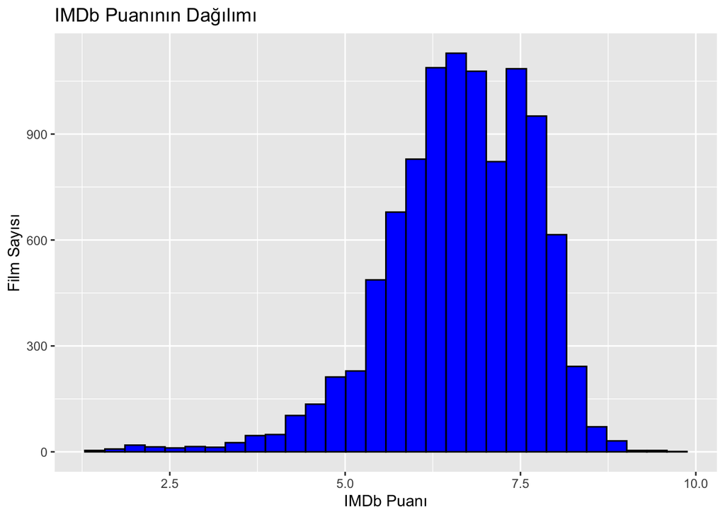

## Q6: Veri analizi

[figure not shown]

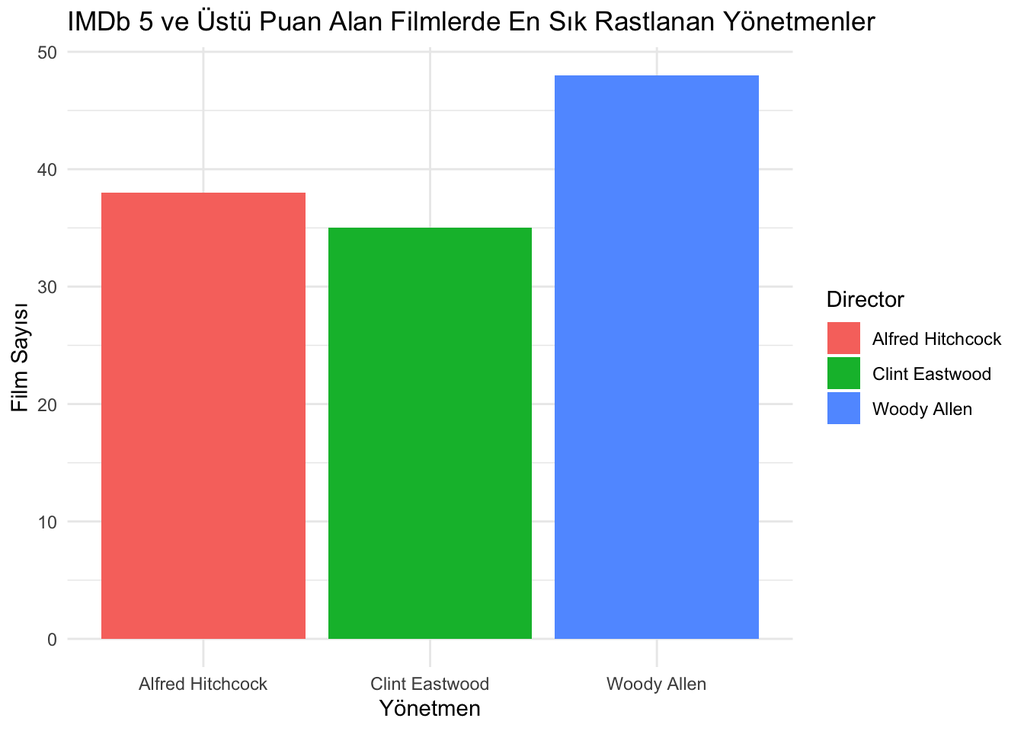

[figure not shown]

[figure not shown]

```
                                          analiz Sonuçları Tablosu
```

[figure not shown]

```
                                  Filmlerin ortalama sürelerinin analizi
```

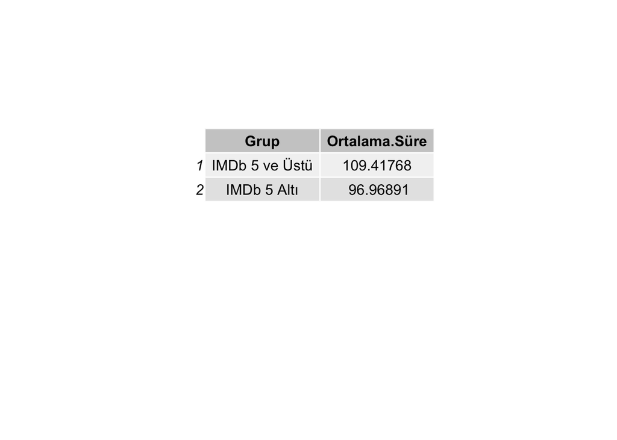

## Q7 : Sonuç değerlendirme, tavsiyeler

Bu bölümde, analizde kullanılan tüm verilere dayalı olarak sonuçları değerlendireceğiz ve gelecekteki çalışmalara yönelik tavsiyelerde bulunacağız.

### Sonuçların Geçerliliği ve Yorumları

Analizimiz, IMDb puanı üzerinde etkili olan film türleri ve yönetmenler hakkında önemli bilgiler sunmaktadır. Özellikle, “IMDb 5 ve Üstü” ve “IMDb 5 Altı” kategorilerindeki popüler türler ve yönetmenler hakkında şunları söyleyebiliriz:

IMDb 5 ve Üstü Kategorisi: Bu kategoride en yaygın türler **Action, Drama ve Comedy’dir**. En çok film çeken yönetmenler ise **Woody Allen, Alfred Hitchcock ve Clint Eastwood**’dur. Ortalama süreleri **109.42** dakikadır.

IMDb 5 Altı Kategorisi: Bu kategoride ise **Action, Comedy ve Horror türleri daha yaygındır**. **Tyler Perry, Uwe Boll ve Jason Friedberg** gibi yönetmenler bu kategoride öne çıkar. Ortalama süreleri **96.97** dakikadır.

Bu sonuçlar, farklı türlerin ve yönetmenlerin IMDb puanını etkileyebileceğini göstermektedir.

### Projenin Başarısı

Proje, geniş veri seti kullanarak çeşitli türlerin ve yönetmenlerin performansını başarıyla analiz etmiştir. Sonuçlar, film yapımcıları ve yönetmenler için önemli bir yol gösterici olabilir. Özellikle, hedeflenen IMDb puanına ulaşmak için en uygun türleri ve yönetmenleri seçme konusunda yardımcı olabilir.

### Sonuçların Kullanımı

Bu sonuçlar, film endüstrisi profesyonelleri, araştırmacılar ve film meraklıları için değerlidir. Film yapımcıları, hedef izleyici kitlesine en uygun türleri ve yönetmenleri seçerek projelerini daha başarılı hale getirebilirler. Aynı zamanda, analizde ortaya çıkan kuvvetli ve zayıf yanlar da göz önünde bulundurularak gelecekteki projelerde daha bilinçli kararlar alınabilir.

### Tavsiyeler

Bu çalışmayı ilerletmek isteyenler için bazı tavsiyeler:

- **Daha Geniş Bir Veri Seti:** Analizi daha geniş bir veri seti ile tekrarlamak, sonuçların genelleştirilebilirliğini artırabilir.
- **Diğer Faktörleri İnceleyin:** Filmlerin IMDb puanını etkileyen diğer faktörleri (oyuncu kadrosu, bütçe, tanıtım) dikkate alarak daha kapsamlı bir analiz yapabilirsiniz.
- **Zaman İçi Değişiklikleri İnceleyin:** Film endüstrisindeki trendler zaman içinde değişebilir, bu nedenle analizi güncel tutmak önemlidir.
- **Daha İleri Görselleştirmeler:** Grafikler ve görsel öğeler kullanarak sonuçları daha etkili bir şekilde iletebilirsiniz.
- **Yönetmen ve Tür Bilgisi:** Analizin sonuçlarına daha fazla ayrıntı eklemek için, film türleri ve yönetmenler hakkında daha fazla bilgi sunabilirsiniz. Örneğin, en çok çalışan yönetmenlerin filmografisi hakkında bilgi verebilirsiniz.